# Stringency index y muertes por COVID en Sudamerica

Introducción a Ciencia de Datos en Salud - Agustín Nava - 2020

# 1 Introducción

Al día de la fecha, hay más de 14 millones de infectados por el virus COVID-19. En marzo de este año la OMS reconoció como pandemia la enfermedad producida por este último, llevando a todos los estados a tomar medidas para disminuir la tasa de contagio. Sin embargo, estas medidas no fueron las mismas en todos los países ni tuvieron el mismo grado de “severidad”.

La Universidad de Oxford generó un parámetro numérico que trata de traducir las medidas gubernamentales a un índice numérico, basándose en indicadores particulares de medidas (cierre de escuelas, espacios de trabajo, cancelación de eventos públicos, restricción de reuniones, cierre de transporte público, entre otras), denominado **“Stringency Index”**.

En este trabajo me propongo analizar la relación entre este índice y la cantidad de muertos por millón en los países de Sudamérica para los que hay datos. *Este trabajo está realizado solo a modo de ejercicio, puesto que la veracidad de las conclusiones finales es despreciable.*

# 2 Cargo las librerías

```r
library(tidyverse)
library(ggplot2)
library(gapminder)
library(knitr)
library(readxl)
library(writexl)
library(readr)
```

# 3 Cargo el .csv

Esta base es diariamente renovada por la Universidad de Oxford, y contiene un registro diario de los infectados/muertos en cada país, además de otros importantes datos demográficos. Se encuentra en: https://ourworldindata.org/coronavirus

```r
COVID <- read_csv("C:/Users/Agu/Downloads/owid-covid-data.csv")
```

# 4 Limpieza y selección de datos

## 4.1 Stringency index

El stringency index es un valor que fue variando con el correr de la pandemia. Entonces, voy a buscar el valor máximo que haya alcanzado en cada país. Como este último se repitió varios días, voy a buscar el registro que tenga la fecha más “actualizada”.

```r
COVID_SI <- COVID %>%
            group_by(location) %>%
            top_n(1, stringency_index) %>%
            filter(date == max(date)) %>%
            ungroup()
```

## 4.2 Selecciono los paises de Sudamerica

```r
COVID_SUD <- COVID_SI %>%
            filter(continent == "South America")
```

Para empezar a explorar la relación entre los datos, hago un grafico.

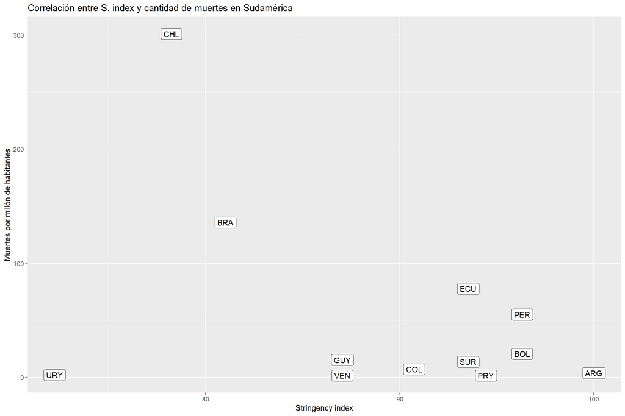

```r
ggplot(data = COVID_SUD, aes(x= stringency_index , y= total_deaths_per_million)) + geom_label(aes(label = iso_code)) +
  labs(title = 'Correlación entre S. index y cantidad de muertes en Sudamérica') +
  xlab("Stringency index") +
  ylab("Muertes por millón de habitantes")
```

Parecería que los países “outliers” son los que menos habitantes tienen.

## 4.3 Me quedo con los paises que tienen más de 5.000.000 de habitantes

```r
COVID_SUD_5 <- COVID_SUD %>%
              filter(population > 5000000)
```

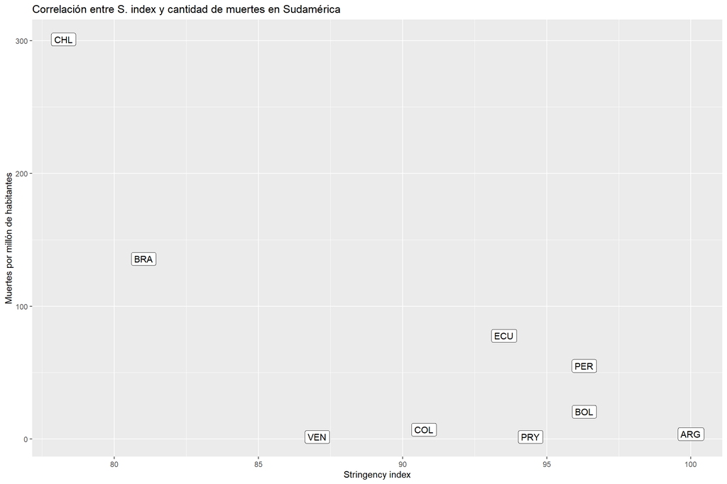

```r
ggplot(data = COVID_SUD_5, aes(x= stringency_index , y= total_deaths_per_million)) + geom_label(aes(label = iso_code)) +
  labs(title = 'Correlación entre S. index y cantidad de muertes en Sudamérica') +
  xlab("Stringency index") +
  ylab("Muertes por millón de habitantes")
```

# 5 Correlación y analisis de P

## 5.1 Mido la correlación entre las variables

```r
cor(COVID_SUD_5$stringency_index,
    COVID_SUD_5$total_deaths_per_million)
```

```
## [1] -0.769241
```

Parecería que hay una correlación inversa *“aceptable”*.

## 5.2 Calculando el valor de P

```r
regresion_lineal <-  lm(total_deaths_per_million ~ stringency_index,
               COVID_SUD_5)
summary(regresion_lineal)
```

```
##
## Call:
## lm(formula = total_deaths_per_million ~ stringency_index, data = COVID_SUD_5)
##
## Residuals:
##      Min       1Q   Median       3Q      Max
## -104.804  -32.843    9.798   38.249  103.757
##
## Coefficients:
##                  Estimate Std. Error t value Pr(>|t|)
## (Intercept)      1004.848    295.271   3.403   0.0114 *
## stringency_index  -10.323      3.241  -3.185   0.0154 *
## ---
## Signif. codes:  0 '***' 0.001 '**' 0.01 '*' 0.05 '.' 0.1 ' ' 1
##
## Residual standard error: 67.46 on 7 degrees of freedom
## Multiple R-squared:  0.5917, Adjusted R-squared:  0.5334
## F-statistic: 10.15 on 1 and 7 DF,  p-value: 0.01538
```

**Con un valor de p de 0.0154, con más del 95% de confianza que el Stringency Index tendría implicancias en el total de muertes por millón.**